## Data cleaning - exercise

- Convert the meter reading column into a character, check that it's been converted, and then convert it back to numeric

```r
consdata$meter_reading <- as.character(consdata$meter_reading)

is.character(consdata$meter_reading)
```

```
## [1] TRUE
```

```r
consdata$meter_reading <- as.numeric(consdata$meter_reading)
```

## Data cleaning

- This method works well for:
  - Numeric/integer to character
  - Character to numeric/integer
  - Integer to numeric
  - Numeric to integer
  - Character to factor
  - Factor to character
  - Numeric to factor
- For factor to numeric, there's an extra step:
  - Before the factors levels can be converted, they need to be converted to characters first:

```r
dataframe$column <- as.numeric(as.character(dataframe$column))
```

## Data cleaning - dates

- Dates in R can be tricky
  - R will not import date values in as dates unless you specify that it should
    - But RStudio's "Import Dataset" feature can be pretty handy here…
  - If you don't, R will import them as characters (which means they'll be converted to factors unless you specify stringsAsFactors = FALSE)
- To convert a character to a date, use the as.Date() function…

## Data cleaning - dates (example)

```r
datetest <- "12/12/2018"
datetest <- as.Date(datetest, format = "%d/%m/%Y")
is(datetest)
```

```
## [1] "Date"     "oldClass"
```

- To convert from a factor to a date, first convert to a character…

## Data cleaning - dates (exercise)

- Our consdata$settlement_date column is currently a factor, convert it to date
- Remeber to convert the column to character first!

```r
consdata$settlement_date <- as.character(consdata$settlement_date)
consdata$settlement_date <- as.Date(consdata$settlement_date, format = "%d/%m/%Y")
```

```r
consdata$settlement_date <- as.Date(as.character(consdata$settlement_date), format = "%d/%m/%Y")
```

## Data cleaning - dates

- Dates can also come in numeric form, calculated as the number of days from a particular origin
- For example, a numeric value of 1, with an origin of 12/12/2018 would correspond to a date value of 13/12/2018
- If your date values are in numeric format, you need to specify the origin in the as.Date() function…

## Data cleaning - dates (example)

```r
datetest <- 17940
datetest <- as.Date(datetest, origin = as.Date("01/01/1970", format = "%d/%m/%Y"))
datetest
```

```
## [1] "2019-02-13"
```

## Data cleaning - dates

- With dates, always specify the format (format codes can be found online and are included in your help sheet)
- There's no is.Date() function in base R
- So to check whether a value is a date, use is()

## Summary statistics

- Before doing any in-depth analysis, it's always a good idea to get some descriptive statistics from your data
- This includes the mean, the median, the standard deviation, and the interquartile range, but the statistics you use will depend on your data
- Getting these values for each column is easy using the built-in functions R provides:

```r
mean()
median()
sd()
quantile()
```

## Summary statistics - exercise

- Find the mean, median, standard deviation, and quantiles for our meter reading column

```r
mean(consdata$meter_reading)
```

```
## [1] 0.8383583
```

```r
median(consdata$meter_reading)
```

```
## [1] 0.85145
```

```r
sd(consdata$meter_reading)
```

```
## [1] 0.05566309
```

```r
quantile(consdata$meter_reading)
```

```
##      0%     25%     50%     75%    100%
## 0.74840 0.77970 0.85145 0.88915 0.91740
```

## Summary statistics

- More often than not however, you'll want summary statistics for more than one column, or maybe broken down by group
- R includes a function that will give you summary statistics for each column (the summary() function):

```r
summary(consdata)
```

```
##  settlement_date      settlement_period metered_entity_type
##  Min.   :2018-01-01   Min.   : 1.00     MPAN:96
##  1st Qu.:2018-01-01   1st Qu.:12.75
##  Median :2018-03-22   Median :24.50
##  Mean   :2018-03-22   Mean   :24.50
##  3rd Qu.:2018-06-10   3rd Qu.:36.25
##  Max.   :2018-06-10   Max.   :48.00
##   metered_entity meter_reading    actual_estimate avg_temperature_c
##  testmpan:96     Min.   :0.7484   A:48            Min.   : 6.670
##                  1st Qu.:0.7797   E:48            1st Qu.: 7.338
##                  Median :0.8515                   Median : 8.280
##                  Mean   :0.8384                   Mean   : 8.929
##                  3rd Qu.:0.8891                   3rd Qu.:10.640
##                  Max.   :0.9174                   Max.   :12.300
```

## Summary statistics by group

- Summary statistics by group are a little bit more complicated as they require the "psych" package
- Once the "psych" package is installed, you can use the describeBy() function to give you summary statistics for each level of a factor in your dataset:
- Note: You'll likely get some error messages if one of your columns isn't numeric, but you can ignore them

```r
describeBy(consdata, consdata$actual_estimate)
```

## Summary statistics by group - exercise

- Install the "psych" package
- Produce summary statistics by Settlement Date

## Summary statistics by group - answer

```r
install.packages("psych")
```

```r
library(psych)
describeBy(consdata, consdata$settlement_date)
```

## Summary statistics by group

[output not shown]

## Plotting

- After calculating your summary statistics, it can be useful to visualise the data to better understand any trends or differences
- For example, we may want to see if there's a difference between the meter reading values for estimates vs. actuals
- We could use a plot to visualise that difference
- There are two good ways to create plots
  - The first uses R's built-in plotting functions
  - The second uses a package called "ggplot2"

## Plotting

- R's main plotting function is plot()
- This function takes the data you want to visualise as it's only required argument, with optional arguments to specify what kind of plot you want
- If you don't specify what kind of plot you want, plot() tries to guess the most appropriate type of plot for your data, and creates it

## Plotting - example

- First off, let's plot the meter reading values of estimates and actuals to see if there's a difference:

```r
plot(x = consdata$actual_estimate, y = consdata$meter_reading)
```

## Plotting - example

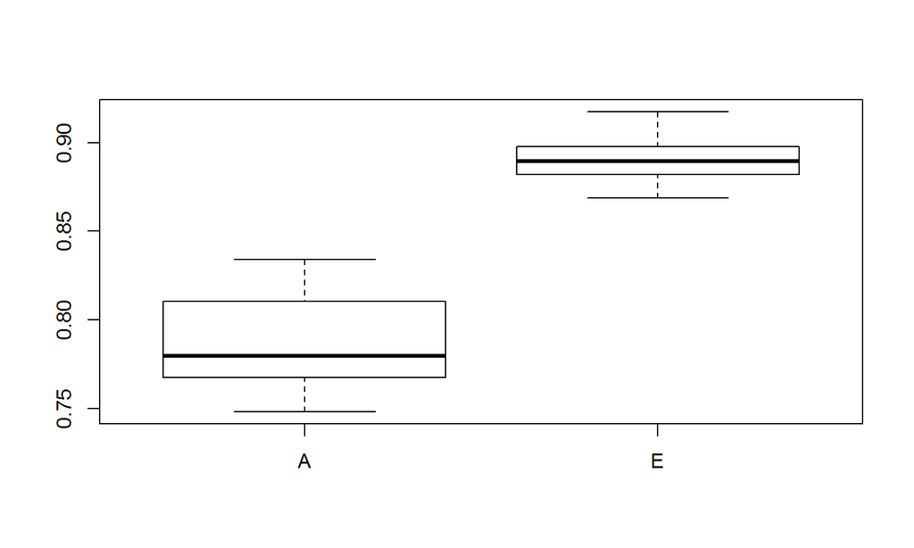

- As you can see, we've specified our x and y axis, but not what type of plot we want
- But the plot() function has guessed that we probably want a boxplot
- Note: you can also force R to create a boxplot using the boxplot() function

## Plotting - example

- Next, we might want to see if there's a correlation between the meter reading and the temperature
- Again, we can use the plot function, specify our x and y axis, and R will guess what the best plot is

```r
plot(x = consdata$meter_reading, y = consdata$avg_temperature_c)
```

## Plotting - example

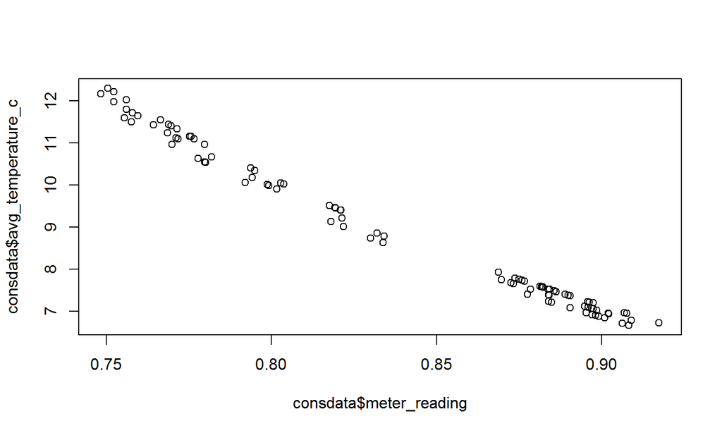

- R has created a scatter plot by default, but we can change the type if we wish using the option "type" argument
- See your help sheet for the different types

## Plotting - exercise

- Create a plot of meter readings against Settlement Periods…

## Plotting - answer

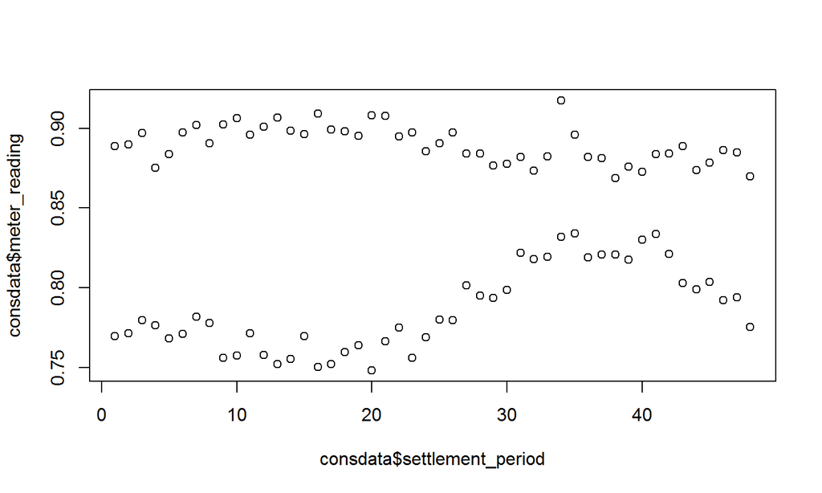

```r
plot(x = consdata$settlement_period, y = consdata$meter_reading)
```

## Histograms - example

- One of the best features of the plotting system in R is how easy it is to make histograms
- You can either use the plot() function and specify "h" as the type, or we can use the hist() function and provide one variable to produce a simple histogram…

```r
hist(consdata$meter_reading)
```

## Histograms - example

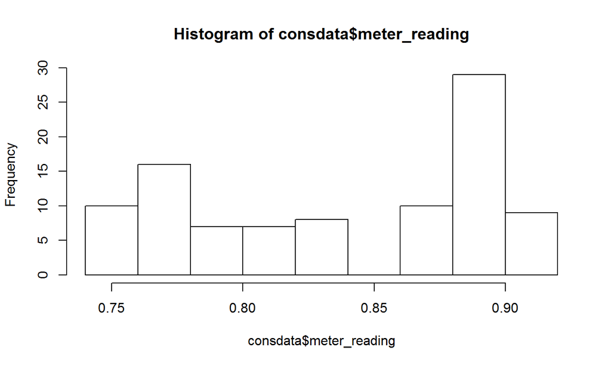

## Customizing your graphs

- To make your graph easier to understand, you may want to…
  - Change the title
  - Change the axis labels
  - Change the points
  - Change the size of the bins for our histogram
- Note: These are a few of the customization options, but there are many, many more

## Customizing your graphs

- Change the title
  - To change the title, all we need to do is specify a "main" parameter in our plot function…

```r
plot(consdata$meter_reading, consdata$avg_temperature_c,
     main = "Correlation between temperature and consumption")
```

- Change the axis labels
  - To change the labels on the axes, we use the "xlab"/"ylab"" parameters…

```r
plot(consdata$meter_reading, consdata$avg_temperature_c,
     main = "Correlation between temperature and consumption",
     xlab = "Meter reading (KwH)",
     ylab = "Temperature (degrees Celsius)")
```

## Customizing your graphs

- Changing the graph points
  - To change the points, we use the "pch" paremeter, and specify a value between 0 and 25…

```r
plot(consdata$meter_reading, consdata$avg_temperature_c,
     main = "Correlation between temperature and consumption",
     xlab = "Meter reading (KwH)",
     ylab = "Temperature (degress Celsius)",
     pch = 19)
```

- Putting those all together…

## Customizing your graphs

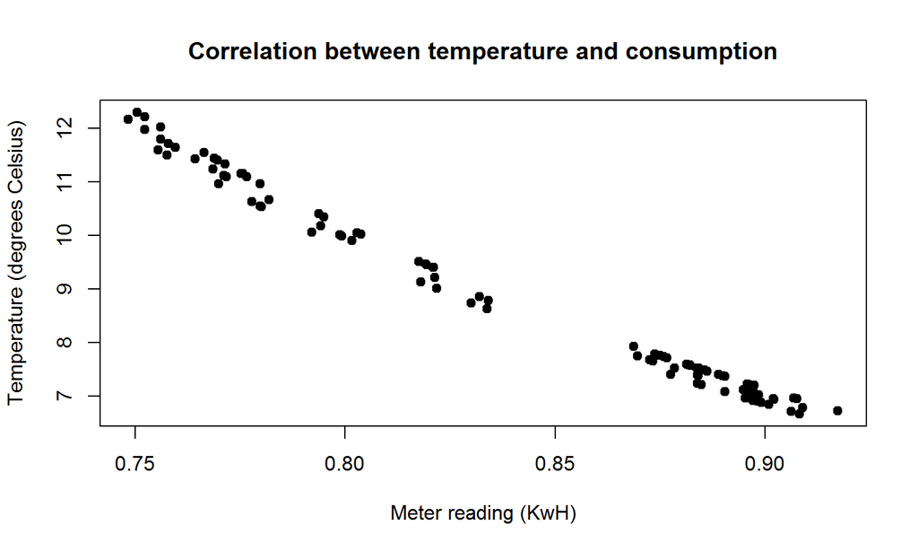

## Customizing your graphs (histograms)

```r
hist(consdata$meter_reading, breaks = 30)
```

## Customizing your graphs (histograms)

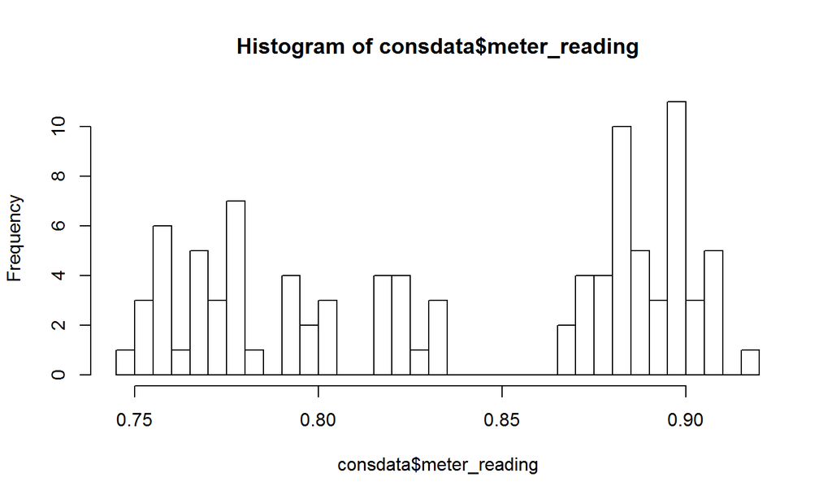

[figure not shown]

## Plotting - final exercise

- Create a plot of your choice, and change the title and axis labels.

## Plotting - conclusion

- In short, R has lots of in-built tools to make quick, simple graphs and plots
- Most types of graph only require a few input parameters, but there's lots of customization options
- In a later module, we'll look at a package called ggplot2, which we'll use to create more complex and professional graphics

## Conclusion

- Installing packages
  - install.packages(), library()
- Loading data
  - read.csv()/read.xlsx()
- Cleaning data
  - Data type checks
  - Data type conversion
    - Look out for dates and factors!
- Plotting
  - plot()/hist()
- Customization
  - "main", "xlab", "ylab", "pch", "breaks"
- Next time…
  - Creating functions
  - For loops
  - If else statements